# Seoul_bikes

## Introduzione

Il data set considerato contiene il numero di bici affittate ogni ora dal servizio di bike sharing della città di Seoul, in Corea del Sud. Ogni record corrisponde ad una certa ora di un certo giorno. I dati sono stati raccolti dalla prima ora del giorno 01/12/2017 all’ultima del giorno 30/11/2018.  
Sono riportate inoltre la data, alcune informazioni metereologiche, un attributo che indica se il giorno considerato era festivo o no e un altro che indica se il servizio di bike sharing era attivo o no quel giorno.  
L’obiettivo è la previsione del numero di bici da rendere disponibili fissati data e ora.

## Packages e librerie

Installiamo i package e importiamo le librerie necessarie.

```r
#install.packages('rdetools')
#install.packages('lubridate')
#install.packages('rdetools')
#install.packages('ggplot2')
#install.packages('Hmisc')
#install.packages('ggridges')
#install.packages('hrbrthemes')
#install.packages("ggcorrplot")
#install.packages('gridExtra')
#install.packages('caret')
library(ggplot2)
library(dplyr)
library(lubridate)
library(ggridges)
library(viridis)
library(ggcorrplot)
library(gridExtra)
library(caret)
```

## Operazioni sul dataset

Carichiamo il dataset.  
Carichiamo gli attributi i cui valori sono stringhe come attributi di tipo factor per poterli trattare come variabili qualitative.

```r
seoul_bikes <- read.csv("SeoulBike.csv", header=TRUE, stringsAsFactors = TRUE)
```

Da indicazione del fornitore del dataset non sono presenti record con valori nulli, verifichiamo comunque che non ce ne siano.

```r
sum(is.na(seoul_bikes))
```

```
## [1] 0
```

Facciamo una veloce analisi degli attributi del dataset per verificare che siano stati caricati correttamente.

```r
str(seoul_bikes)
```

```
## 'data.frame':    8760 obs. of  14 variables:
##  $ Date                     : Factor w/ 365 levels "01/01/2018","01/02/2018",..: 12 12 12 12 12 12 12 12 12 12 ...
##  $ Rented.Bike.Count        : int  254 204 173 107 78 100 181 460 930 490 ...
##  $ Hour                     : int  0 1 2 3 4 5 6 7 8 9 ...
##  $ Temperature.蚓.          : num  -5.2 -5.5 -6 -6.2 -6 -6.4 -6.6 -7.4 -7.6 -6.5 ...
##  $ Humidity...              : int  37 38 39 40 36 37 35 38 37 27 ...
##  $ Wind.speed..m.s.         : num  2.2 0.8 1 0.9 2.3 1.5 1.3 0.9 1.1 0.5 ...
##  $ Visibility..10m.         : int  2000 2000 2000 2000 2000 2000 2000 2000 2000 1928 ...
##  $ Dew.point.temperature.蚓.: num  -17.6 -17.6 -17.7 -17.6 -18.6 -18.7 -19.5 -19.3 -19.8 -22.4 ...
##  $ Solar.Radiation..MJ.m2.  : num  0 0 0 0 0 0 0 0 0.01 0.23 ...
##  $ Rainfall.mm.             : num  0 0 0 0 0 0 0 0 0 0 ...
##  $ Snowfall..cm.            : num  0 0 0 0 0 0 0 0 0 0 ...
##  $ Seasons                  : Factor w/ 4 levels "Autumn","Spring",..: 4 4 4 4 4 4 4 4 4 4 ...
##  $ Holiday                  : Factor w/ 2 levels "Holiday","No Holiday": 2 2 2 2 2 2 2 2 2 2 ...
##  $ Functioning.Day          : Factor w/ 2 levels "No","Yes": 2 2 2 2 2 2 2 2 2 2 ...
```

Gli attributi sono stati caricati correttamente.  
Il numero di bici affittate ogni ora è contenuto nell’attributo ‘Rented.Bike.Count’. Abbiamo poi indicazioni temporali quali data e ora, vari indicatori metereologici e la rispettiva stagione. L’attributo ‘Holiday’ indica se il giorno era festivo o no, l’attributo ‘Functioning.Day’ indica se il servizio era attivo o no quel giorno.  
Cambiamo ora i nomi delle colonne affinchè siano più facilmente utilizzabili.

```r
colnames(seoul_bikes) <- c("Date", "Rent_bike","Hour", "Temp", "Hum", "WS", "Vis",
                           "DPT", "SR", "RF", "SF", "Seas", "Hol", "FD")
```

Facciamo un’analisi riassunitva delle distribuzioni degli attributi del dataset.

```r
summary(seoul_bikes)
```

```
##          Date        Rent_bike           Hour            Temp
##  01/01/2018:  24   Min.   :   0.0   Min.   : 0.00   Min.   :-17.80
##  01/02/2018:  24   1st Qu.: 191.0   1st Qu.: 5.75   1st Qu.:  3.50
##  01/03/2018:  24   Median : 504.5   Median :11.50   Median : 13.70
##  01/04/2018:  24   Mean   : 704.6   Mean   :11.50   Mean   : 12.88
##  01/05/2018:  24   3rd Qu.:1065.2   3rd Qu.:17.25   3rd Qu.: 22.50
##  01/06/2018:  24   Max.   :3556.0   Max.   :23.00   Max.   : 39.40
##  (Other)   :8616
##       Hum              WS             Vis            DPT
##  Min.   : 0.00   Min.   :0.000   Min.   :  27   Min.   :-30.600
##  1st Qu.:42.00   1st Qu.:0.900   1st Qu.: 940   1st Qu.: -4.700
##  Median :57.00   Median :1.500   Median :1698   Median :  5.100
##  Mean   :58.23   Mean   :1.725   Mean   :1437   Mean   :  4.074
##  3rd Qu.:74.00   3rd Qu.:2.300   3rd Qu.:2000   3rd Qu.: 14.800
##  Max.   :98.00   Max.   :7.400   Max.   :2000   Max.   : 27.200
##
##        SR               RF                SF              Seas
##  Min.   :0.0000   Min.   : 0.0000   Min.   :0.00000   Autumn:2184
##  1st Qu.:0.0000   1st Qu.: 0.0000   1st Qu.:0.00000   Spring:2208
##  Median :0.0100   Median : 0.0000   Median :0.00000   Summer:2208
##  Mean   :0.5691   Mean   : 0.1487   Mean   :0.07507   Winter:2160
##  3rd Qu.:0.9300   3rd Qu.: 0.0000   3rd Qu.:0.00000
##  Max.   :3.5200   Max.   :35.0000   Max.   :8.80000
##
##          Hol         FD
##  Holiday   : 432   No : 295
##  No Holiday:8328   Yes:8465
##
##
##
##
##
```

La variabile ‘Date’ è una variabile qualitativa con 365 modalità ognuna ripetuta 24 volte e risulta quindi poco utile. Ricaviamo allora da essa il mese e inseriamo i valori ottenuti in una nuova colonna del dataset chiamata ‘Month’. Per ora inseriamo la variabile ‘Month’ come variabile qualitativa.

```r
seoul_bikes[,'Date'] <- as.Date.character(seoul_bikes[,'Date'], format="%d/%m/%Y")

seoul_bikes[,'Month'] <- month(seoul_bikes[,'Date'])
seoul_bikes[,'Month'] <- as.factor(seoul_bikes[,'Month'])
str(seoul_bikes)
```

```
## 'data.frame':    8760 obs. of  15 variables:
##  $ Date     : Date, format: "2017-12-01" "2017-12-01" ...
##  $ Rent_bike: int  254 204 173 107 78 100 181 460 930 490 ...
##  $ Hour     : int  0 1 2 3 4 5 6 7 8 9 ...
##  $ Temp     : num  -5.2 -5.5 -6 -6.2 -6 -6.4 -6.6 -7.4 -7.6 -6.5 ...
##  $ Hum      : int  37 38 39 40 36 37 35 38 37 27 ...
##  $ WS       : num  2.2 0.8 1 0.9 2.3 1.5 1.3 0.9 1.1 0.5 ...
##  $ Vis      : int  2000 2000 2000 2000 2000 2000 2000 2000 2000 1928 ...
##  $ DPT      : num  -17.6 -17.6 -17.7 -17.6 -18.6 -18.7 -19.5 -19.3 -19.8 -22.4 ...
##  $ SR       : num  0 0 0 0 0 0 0 0 0.01 0.23 ...
##  $ RF       : num  0 0 0 0 0 0 0 0 0 0 ...
##  $ SF       : num  0 0 0 0 0 0 0 0 0 0 ...
##  $ Seas     : Factor w/ 4 levels "Autumn","Spring",..: 4 4 4 4 4 4 4 4 4 4 ...
##  $ Hol      : Factor w/ 2 levels "Holiday","No Holiday": 2 2 2 2 2 2 2 2 2 2 ...
##  $ FD       : Factor w/ 2 levels "No","Yes": 2 2 2 2 2 2 2 2 2 2 ...
##  $ Month    : Factor w/ 12 levels "1","2","3","4",..: 12 12 12 12 12 12 12 12 12 12 ...
```

Dalla variabile ‘Date’ possiamo ricavare anche il giorno della settimana. Ogni giorno conta 24 record, uno per ogni ora. Distinguiamo i giorni con i numeri da 1 a 7. Il numero 1 è associato al lunedì e gli altri a seguire. Creiamo una lista di lunghezza 24*7 dove gli elementi saranno i numeri da 1 a 7 ripetuti ciascuno 24 volte. La lista parte dal numero 5 poichè il primo giorno di osservazioni era un venerdì. Questa lista rappresenta una settimana di osservazioni. Inseriamo questa lista quante volte possibile in una nuova colonna del dataset chiamata ‘Day’. Alla fine di questo processo restano 24 record senza valore per la colonna ‘Day’. Quei 24 record vengono riempiti con il valore 5. Per ora inseriamo la variabile ‘Day’ come variabile qualitativa.

```r
settimana <- c()
iter <- list(5,6,7,1,2,3,4)
for(i in iter){
  giorno <- rep(i, 24)
  settimana <- c(settimana, giorno)
}
length(settimana)
```

```
## [1] 168
```

```r
anno <- c()
for(i in 1:52){
  anno <- c(anno, settimana)
}
length(anno)
```

```
## [1] 8736
```

```r
ultimo_giorno <- rep(5, 24)
anno <- c(anno, ultimo_giorno)

length(anno)
```

```
## [1] 8760
```

```r
seoul_bikes['Day'] <- anno
seoul_bikes[, 'Day'] <- as.factor(seoul_bikes[, 'Day'])
```

```r
str(seoul_bikes)
```

```
## 'data.frame':    8760 obs. of  16 variables:
##  $ Date     : Date, format: "2017-12-01" "2017-12-01" ...
##  $ Rent_bike: int  254 204 173 107 78 100 181 460 930 490 ...
##  $ Hour     : int  0 1 2 3 4 5 6 7 8 9 ...
##  $ Temp     : num  -5.2 -5.5 -6 -6.2 -6 -6.4 -6.6 -7.4 -7.6 -6.5 ...
##  $ Hum      : int  37 38 39 40 36 37 35 38 37 27 ...
##  $ WS       : num  2.2 0.8 1 0.9 2.3 1.5 1.3 0.9 1.1 0.5 ...
##  $ Vis      : int  2000 2000 2000 2000 2000 2000 2000 2000 2000 1928 ...
##  $ DPT      : num  -17.6 -17.6 -17.7 -17.6 -18.6 -18.7 -19.5 -19.3 -19.8 -22.4 ...
##  $ SR       : num  0 0 0 0 0 0 0 0 0.01 0.23 ...
##  $ RF       : num  0 0 0 0 0 0 0 0 0 0 ...
##  $ SF       : num  0 0 0 0 0 0 0 0 0 0 ...
##  $ Seas     : Factor w/ 4 levels "Autumn","Spring",..: 4 4 4 4 4 4 4 4 4 4 ...
##  $ Hol      : Factor w/ 2 levels "Holiday","No Holiday": 2 2 2 2 2 2 2 2 2 2 ...
##  $ FD       : Factor w/ 2 levels "No","Yes": 2 2 2 2 2 2 2 2 2 2 ...
##  $ Month    : Factor w/ 12 levels "1","2","3","4",..: 12 12 12 12 12 12 12 12 12 12 ...
##  $ Day      : Factor w/ 7 levels "1","2","3","4",..: 5 5 5 5 5 5 5 5 5 5 ...
```

La colonna FD(Functioning Day) può assumere valori “Yes” o “No”, il valore “No” indica che il servizio di bike sharing non è funzionante. Quindi in corrispondenza dei record con valore di ‘FD’ uguale a “No” il valore di ‘Rented_bike’ è sempre uguale a 0. Volendo prevedere il numero di bici da rendere disponibili non siamo interessati ai record con valore di FD uguale a “No”, quindi li eliminiamo. Successivamente eliminiamo anche la colonna FD poichè ora assume soltanto valori “Yes” e risulta dunque inutile.

```r
seoul_bikes<-seoul_bikes[!(seoul_bikes$FD=="No"), ]
seoul_bikes <- subset(seoul_bikes, select = - FD)
```

```r
##cambiamo l'ordine delle variabili, dopo ci sarà utile
seoul_bikes <- seoul_bikes[ , c("Date", "Rent_bike","Hour", "Temp", "Hum", "WS",
                                "Vis", "DPT", "SR", "RF", "SF", "Month","Day","Seas", "Hol")]
str(seoul_bikes)
```

```
## 'data.frame':    8465 obs. of  15 variables:
##  $ Date     : Date, format: "2017-12-01" "2017-12-01" ...
##  $ Rent_bike: int  254 204 173 107 78 100 181 460 930 490 ...
##  $ Hour     : int  0 1 2 3 4 5 6 7 8 9 ...
##  $ Temp     : num  -5.2 -5.5 -6 -6.2 -6 -6.4 -6.6 -7.4 -7.6 -6.5 ...
##  $ Hum      : int  37 38 39 40 36 37 35 38 37 27 ...
##  $ WS       : num  2.2 0.8 1 0.9 2.3 1.5 1.3 0.9 1.1 0.5 ...
##  $ Vis      : int  2000 2000 2000 2000 2000 2000 2000 2000 2000 1928 ...
##  $ DPT      : num  -17.6 -17.6 -17.7 -17.6 -18.6 -18.7 -19.5 -19.3 -19.8 -22.4 ...
##  $ SR       : num  0 0 0 0 0 0 0 0 0.01 0.23 ...
##  $ RF       : num  0 0 0 0 0 0 0 0 0 0 ...
##  $ SF       : num  0 0 0 0 0 0 0 0 0 0 ...
##  $ Month    : Factor w/ 12 levels "1","2","3","4",..: 12 12 12 12 12 12 12 12 12 12 ...
##  $ Day      : Factor w/ 7 levels "1","2","3","4",..: 5 5 5 5 5 5 5 5 5 5 ...
##  $ Seas     : Factor w/ 4 levels "Autumn","Spring",..: 4 4 4 4 4 4 4 4 4 4 ...
##  $ Hol      : Factor w/ 2 levels "Holiday","No Holiday": 2 2 2 2 2 2 2 2 2 2 ...
```

## Analisi delle variabili

Iniziamo con alcune analisi della distribuzione della variabile target “Rent_bike”, prima in generale e poi considerando anche altre variabili.

```r
#settiamo alcuni parametri di formattazione dei grafici che utilizzeremo in seguito
My_theme <- function() {
   theme(axis.title=element_text(size=16), axis.text=element_text(size=14),
         legend.title = element_text(size=16), legend.text = element_text(size=14))
}

My_theme_2 <- function() {
   theme(axis.title=element_text(size=14), axis.text=element_text(size=12),
         legend.title = element_text(size=16), legend.text = element_text(size=14))
}
```

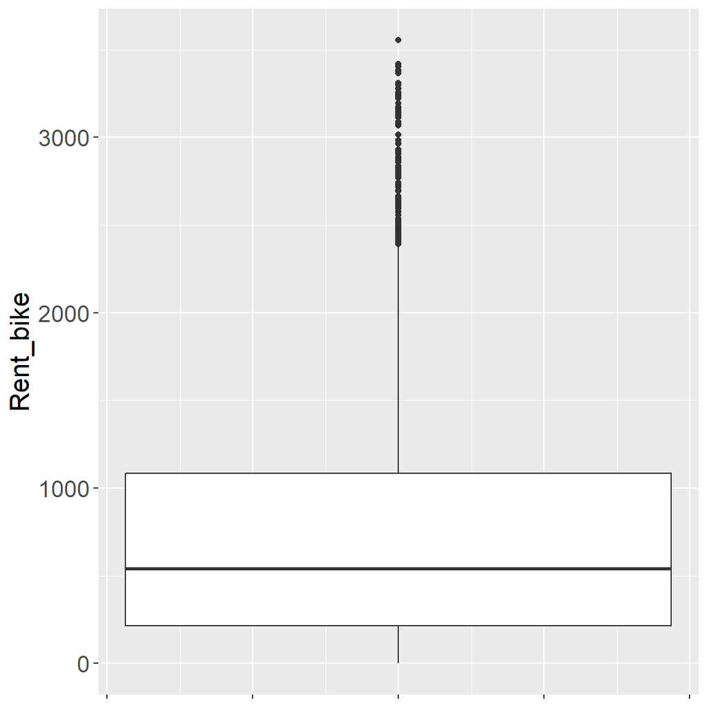

```r
p <- ggplot(seoul_bikes, aes(y = Rent_bike)) + geom_boxplot() + labs(y="Rent_bike") +
       theme(axis.title=element_text(size=16), axis.text=element_text(size=14)) +
       theme(axis.text.x = element_blank())
p
```

Osserviamo che i valori della distribuzione superiori alla mediana sono molto più dispersi che i valori inferiori. Sono inoltre presenti numerosi outlier superiori.  
Andiamo ora ad analizzare la distribuzione del numero di bici affittate in base alla stagione. Utilizziamo dei violin plot per poter ottenere un’indicazione grafica dell’intera distribuzione e non solo dei valori principali.

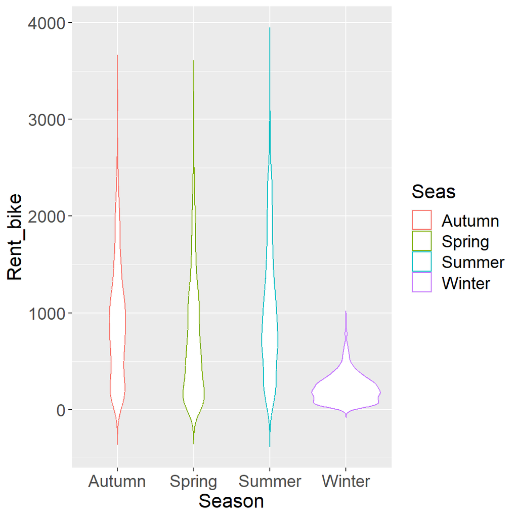

```r
p <- ggplot(seoul_bikes, aes(x=Seas, y=Rent_bike, col=Seas)) + geom_violin(trim=FALSE) +
       labs(x="Season", y="Rent_bike") + My_theme()
p
```

Per le stagioni Autunno, Primavera ed Estate non individuiamo intervalli dei valori di Rent_bike con una particolare concentrazione di osservazioni, i valori risultano molto distribuiti. Per quanto riguarda la stagione invernale osserviamo una forte concentrazione di osservazioni nell’intervallo da 0 a 300 circa, inoltre i valori sono molto più bassi che per le altre stagioni.  
Continuiamo analizzando l’andamento del numero di bici affittate per ogni mese dell’anno. Utilizziamo quindi la colonna ‘Month’.

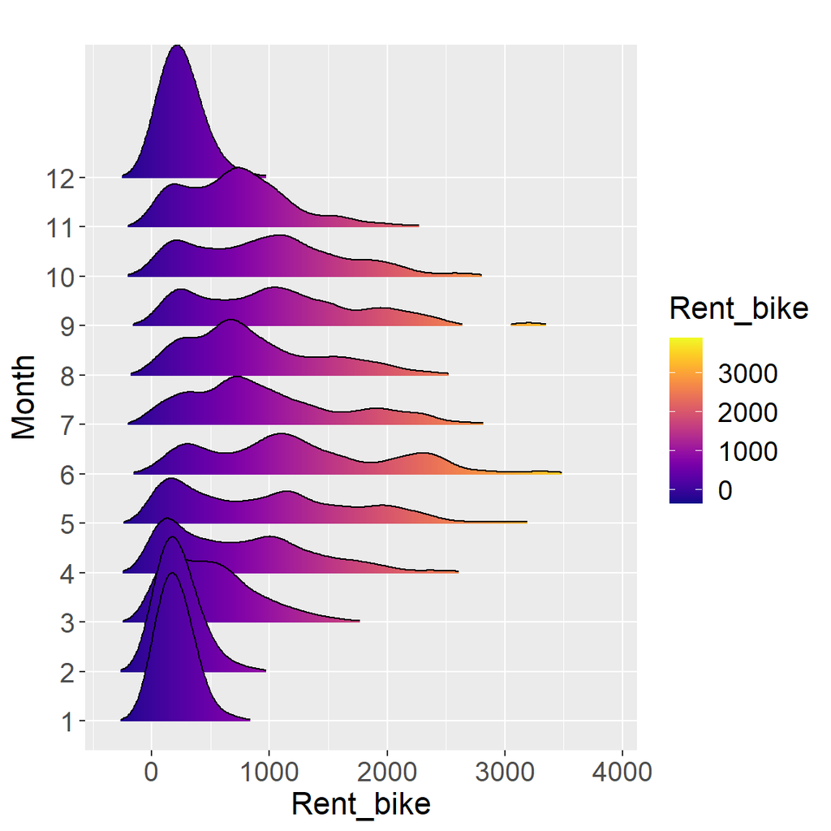

```r
ggplot(seoul_bikes, aes(x = Rent_bike, y = Month, fill = ..x..)) +
  geom_density_ridges_gradient(scale = 3, rel_min_height = 0.01) +
  scale_fill_viridis(name = "Rent_bike", option = "C") +
  labs(title = ' ') +
   My_theme()
```

Vengono confermate le impressioni dell’analisi precedente, nei mesi invernali il servizio è utilizzato notevolmente meno. Le osservazioni con i valori più alti di bici utilizzate sono a Maggio e a Giugno.  
Analizziamo ora la distribuzione del numero di bici utilizzate nei vari giorni della settimana. Facciamo riferimento alla colonna ‘Day’.

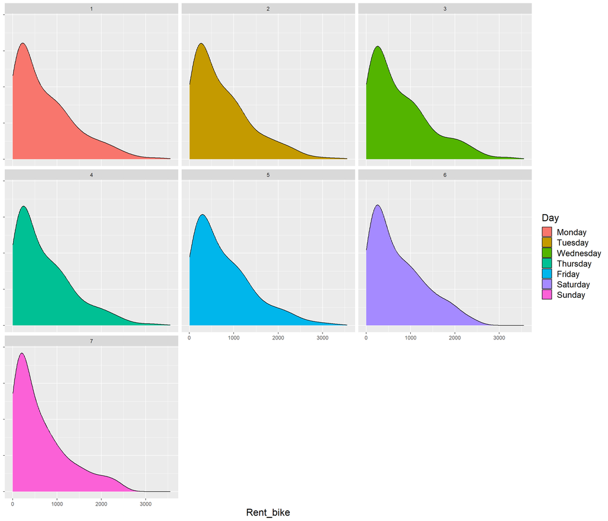

```r
ggplot(data=seoul_bikes, aes(x=Rent_bike, group=Day, fill=Day)) +
    geom_density(adjust=1.5) +
    facet_wrap(~Day) +
    scale_fill_discrete(name = "Day", labels = c("Monday", "Tuesday", "Wednesday", "Thursday",
    "Friday", "Saturday", "Sunday")) + theme(axis.text.y = element_blank(), axis.title.y=element_blank(),
     legend.title = element_text(size=16), legend.text = element_text(size=14), axis.title.x=element_text(size=16))
```

Osserviamo che per i giorni dal lunedi al sabato la distribuzione è molto simile. La domenica osserviamo un picco più pronunciato per valori piccoli di ‘Rent_bike’, si ha quindi un maggior numero di osservazioni con valori piccoli di ‘Rent_bike’. Questo significa che la domenica vengono normalmente utilizzate meno bici.  
Analizziamo ora la distribuizone del numero di bici affittate per giorni festivi e non festivi. La colonna di riferimento è ‘Hol’(Holiday).

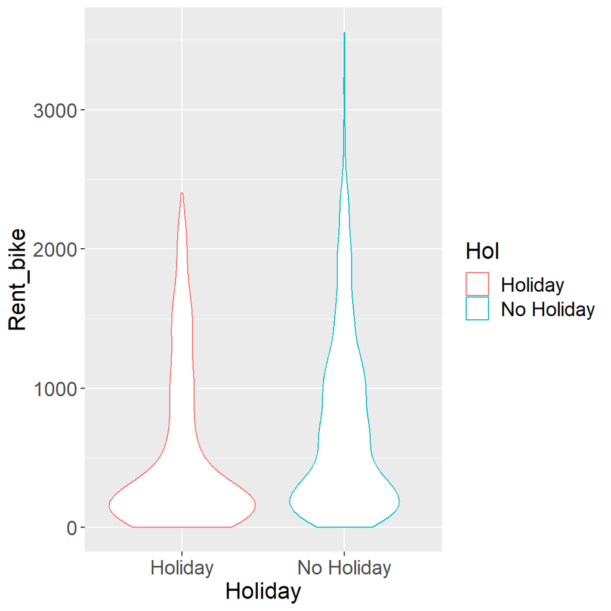

```r
p <- ggplot(seoul_bikes, aes(x=Hol, y=Rent_bike, col=Hol)) + geom_violin() + labs(x="Holiday", y="Rent_bike") +
      My_theme()
p
```

Dai violin plot rappresentati possiamo dedurre che il serivzio di bike sharing è maggiormente utilizzato nei giorni feriali rispetto ai giorni festivi, con valori che arrivano a superare le 3000 bici affittate in un’ora. Ricordiamo comunque che il campione dei giorni feriali è molto superiore a quello dei giorni festivi quindi non possiamo giungere a conclusioni certe. Andiamo ora a studiare l’andamento del numero di bici affittate per ogni ora, facciamo quindi riferimento alla colonna ‘Hour’.

```r
##trasformo Hour in factor, passaggio necessario per la realizzazione del seguente grafico
seoul_bikes[,'Hour'] <- as.factor(seoul_bikes[,'Hour'])
```

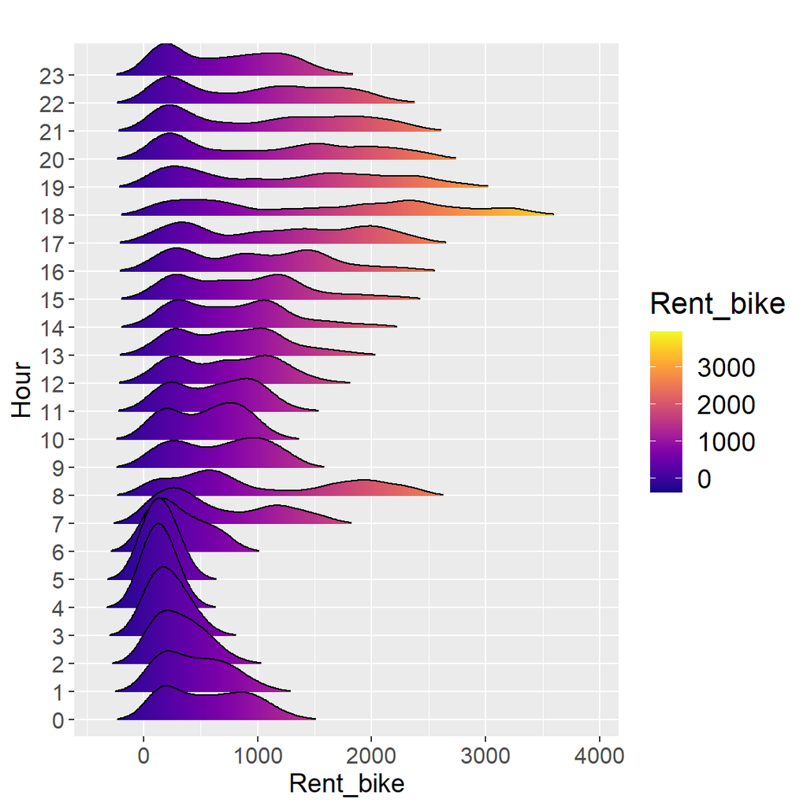

```r
ggplot(seoul_bikes, aes(x = Rent_bike, y = Hour, fill = ..x..)) +
  geom_density_ridges_gradient(scale = 3, rel_min_height = 0.01) +
  scale_fill_viridis(name = "Rent_bike", option = "C") +
  labs(title = ' ') +
  My_theme_2()
```

Osserviamo che le ore con i valori di bici affittate più alti sono le 8 e poi tra le 18 e le 22, ore vicine agli orari di inizio e fine della giornata lavorativa. Questa osservazione, unita al fatto che il numero di bici affitate è maggiore nei giorni feriali rispetto a quelli festivi e che la domenica vengono utilizzate meno bici, può far suppore che le bici del servizio di bike sharing siano spesso utilizzate dagli abitanit di Seoul per andare e tornare da lavoro.

Andiamo ora ad analizzare le correlazioni tra le variabili numeriche del dataset. Al fine della costruzione del modello di regressione lineare vogliamo individuare le variabili maggiormente correlate con la variabile target e scoprire eventuali correlazioni tra le variabili esplicative. Variabili esplicative fortemente correlate non possono infatti essere inserite contemporaneamente nel modello perchè potrebbero causare problemi di multicollinearità. Proviamo ora ad inserire le variabili ‘Month’ e ‘Day’ come variabili quantitative per osservare se potrebbero risultare utili.

```r
##trasformo le variabili factor in integer, passaggio necessario per poter calcolare le correlazioni
seoul_bikes[,'Hour'] <- as.integer(seoul_bikes[,'Hour'])
seoul_bikes[,'Month'] <- as.integer(seoul_bikes[,'Month'])
seoul_bikes[,'Day'] <- as.integer(seoul_bikes[,'Day'])
```

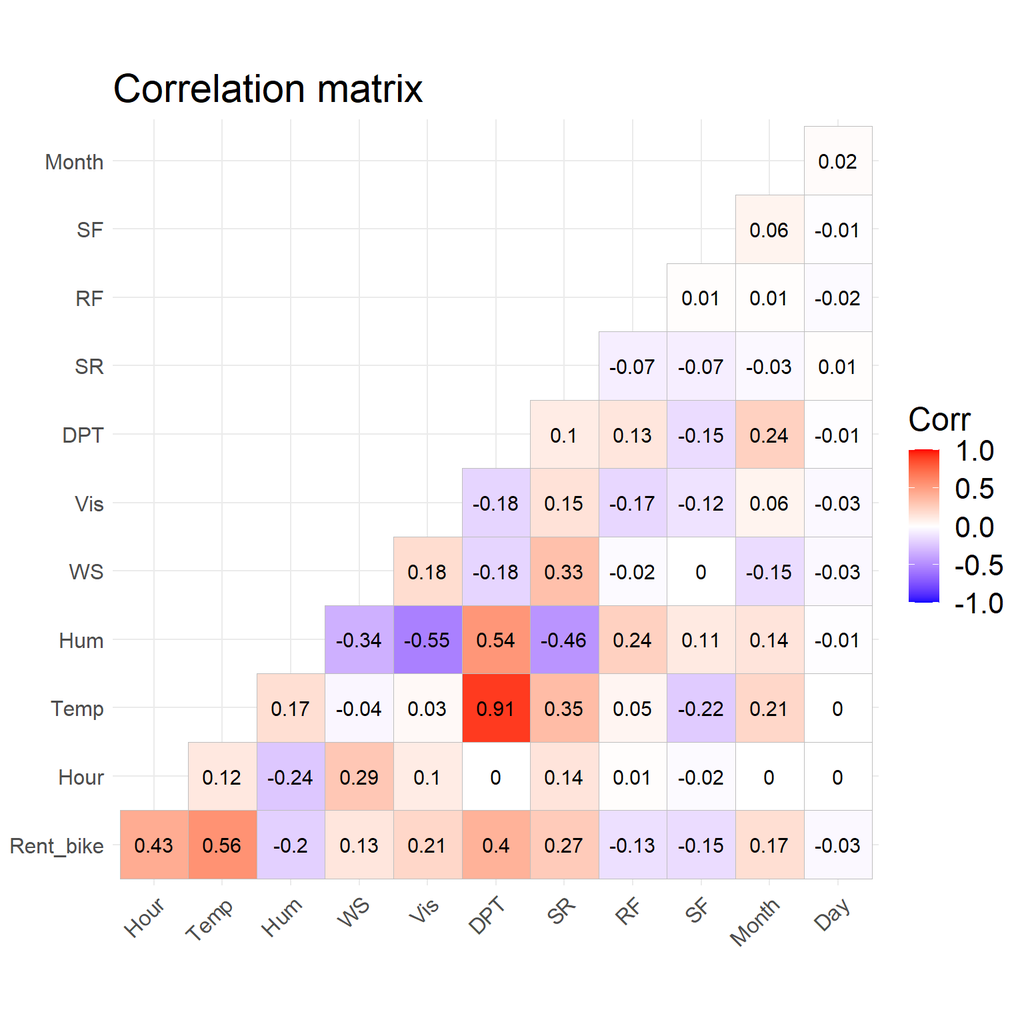

```r
seoul_cor <- cor(seoul_bikes[2:13])

ggcorrplot(seoul_cor, hc.order = FALSE, type = 'lower', lab = TRUE, title = 'Correlation matrix') +
  theme(plot.title = element_text(size=22), legend.title = element_text(size=18),
        legend.text = element_text(size=16))
```

Le variabili maggiormente correlate con la variabile target ‘Rent_bike’ sono ‘Hour’ e ‘Temp’(Temperature). ‘Temp’ risulta fortemente correlata con ‘DPT’(Dew Point Temperature). ‘Month’ e ‘Day’ non risultano utili come variabili quantitative quindi le utilizzeremo come variabili qualitative.  
Visualizziamo graficamente la correlazione tra ‘Hour’ e ‘Rent_bike’ e tra ‘Temp’ e ‘Rent_bike’.

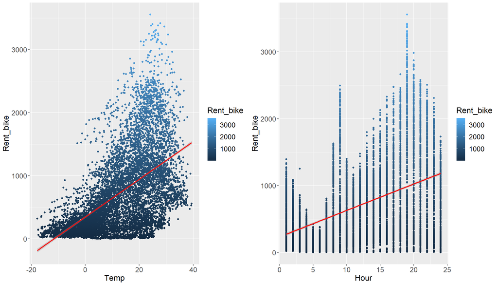

```r
p1 <- ggplot(seoul_bikes, aes(Temp, Rent_bike, colour = Rent_bike)) +
       geom_point() + My_theme()
p1 <- p1 + geom_smooth(method = "lm", se = TRUE, color='red')

p2 <- ggplot(seoul_bikes, aes(Hour, Rent_bike, colour = Rent_bike)) +
       geom_point() + My_theme()
p2 <- p2 + geom_smooth(method = "lm", se = TRUE, color='red')

grid.arrange(p1, p2, ncol=2)
```

## Sviluppo e training del modello

Procediamo ora alla costruzione del modello.  
Utilizzeremo l’80% dei record del dataset per la fase di training. Il restante 20% lo utilizzeremo per la fase di testing. Dividiamo quindi il dataset iniziale.

```r
set.seed(100)

trainingRowIndex <- sample(1:nrow(seoul_bikes), 0.8*nrow(seoul_bikes))
seoul_bikes_training <- seoul_bikes[trainingRowIndex, ]

seoul_bikes_test  <- seoul_bikes[-trainingRowIndex, ]
seoul_bikes_test <- seoul_bikes_test
```

```r
nrow(seoul_bikes)
```

```
## [1] 8465
```

```r
nrow(seoul_bikes_test)
```

```
## [1] 1693
```

```r
nrow(seoul_bikes_training)
```

```
## [1] 6772
```

Costruiamo il primo modello. Inseriamo come unica variabile esplicativa ‘Temp’ che era quella che risultava maggiormente correlata con la variabile target.

```r
seoul.lm <- lm(seoul_bikes_training$Rent_bike ~ seoul_bikes_training$Temp)
summary(seoul.lm)
```

```
##
## Call:
## lm(formula = seoul_bikes_training$Rent_bike ~ seoul_bikes_training$Temp)
##
## Residuals:
##     Min      1Q  Median      3Q     Max
## -1069.6  -320.0   -58.1   226.6  2494.1
##
## Coefficients:
##                           Estimate Std. Error t value Pr(>|t|)
## (Intercept)               345.1142     9.3645   36.85   <2e-16 ***
## seoul_bikes_training$Temp  29.7431     0.5333   55.77   <2e-16 ***
## ---
## Signif. codes:  0 '***' 0.001 '**' 0.01 '*' 0.05 '.' 0.1 ' ' 1
##
## Residual standard error: 530.6 on 6770 degrees of freedom
## Multiple R-squared:  0.3148, Adjusted R-squared:  0.3147
## F-statistic:  3110 on 1 and 6770 DF,  p-value: < 2.2e-16
```

Studiamo il grafico dei residui del modello appena costruito per vedere se individuiamo un andamento simile ad una funzione nota. Questo suggerirebbe un nuovo inserimento di ‘Temp’ nel modello come variabile di tale funzione.

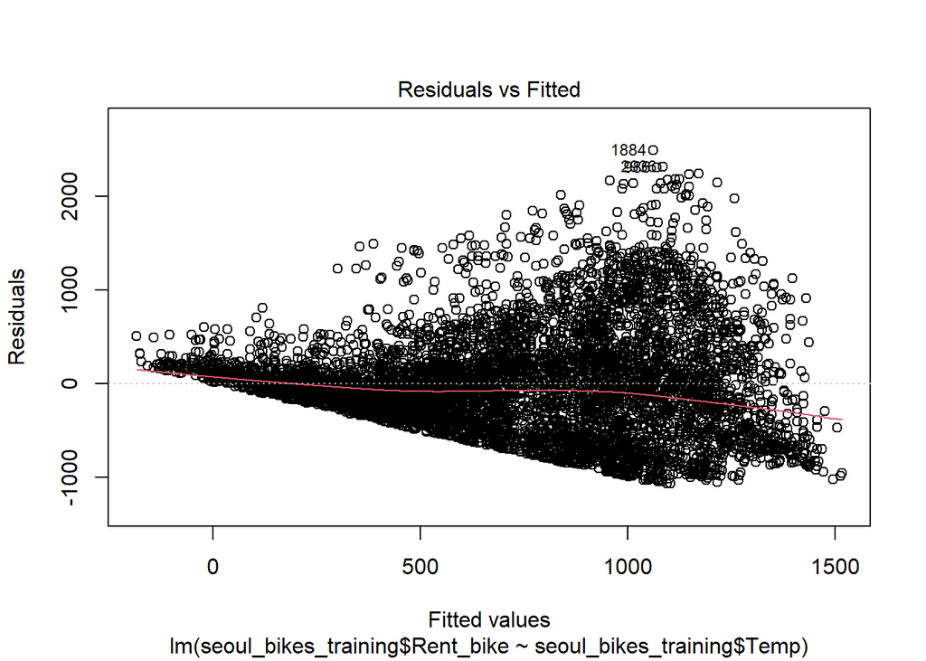

```r
plot(seoul.lm, which = c(1))
```

Non idiviudiamo un andamento noto. La prossima variabile che andiamo ad inserire è ‘Hour’ poichè era la seconda più correlata con ‘Rent_bike’. Come sopra cerchiamo una funzione che potrebbe rendere più proficuo l’inserimento di ‘Hour’.

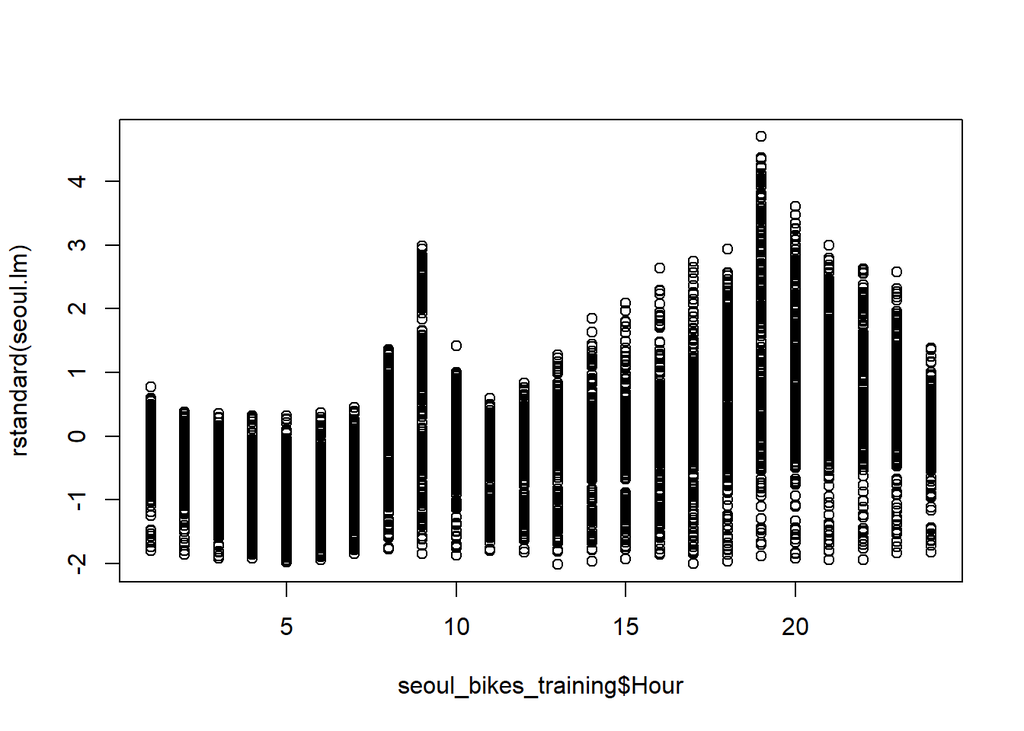

```r
plot(rstandard(seoul.lm) ~ seoul_bikes_training$Hour)
```

Non indivudiamo un andamento noto quindi inseriamo ‘Hour’ come variabile lineare.

```r
seoul.plm <- lm(seoul_bikes_training$Rent_bike ~ seoul_bikes_training$Temp + seoul_bikes_training$Hour)
summary(seoul.plm)
```

```
##
## Call:
## lm(formula = seoul_bikes_training$Rent_bike ~ seoul_bikes_training$Temp +
##     seoul_bikes_training$Hour)
##
## Residuals:
##      Min       1Q   Median       3Q      Max
## -1346.21  -294.19   -38.52   234.88  2294.53
##
## Coefficients:
##                           Estimate Std. Error t value Pr(>|t|)
## (Intercept)               -54.8913    12.8763  -4.263 2.04e-05 ***
## seoul_bikes_training$Temp  27.5854     0.4804  57.418  < 2e-16 ***
## seoul_bikes_training$Hour  34.2921     0.8378  40.933  < 2e-16 ***
## ---
## Signif. codes:  0 '***' 0.001 '**' 0.01 '*' 0.05 '.' 0.1 ' ' 1
##
## Residual standard error: 475.1 on 6769 degrees of freedom
## Multiple R-squared:  0.4507, Adjusted R-squared:  0.4506
## F-statistic:  2777 on 2 and 6769 DF,  p-value: < 2.2e-16
```

Procediamo come sopra.

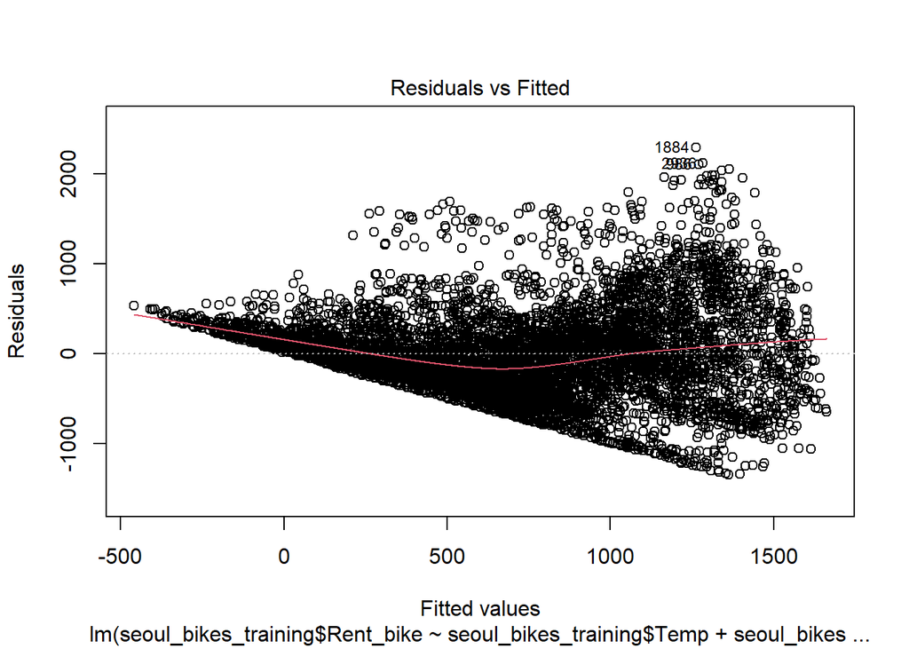

```r
plot(seoul.plm, which = c(1))
```

Non individuiamo un andamento noto.  
La terza variabile più correlata è ‘DPT’ ma non la inseriamo perchè è fortemente correlata con ‘Temp’. Non inseriamo neanche ‘SR’(Solar Radiation) perchè ha una correlazione più forte con ‘Temp’ che con la variabile target. Inseriamo quindi ‘Vis’(Visibility), procediamo come sopra.

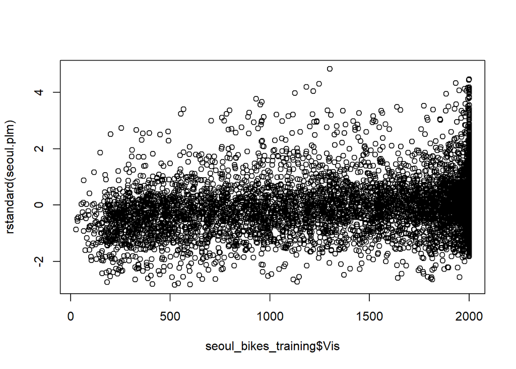

```r
plot(rstandard(seoul.plm) ~ seoul_bikes_training$Vis)
```

Non individuiamo un andamento noto, quindi inseriamo ‘Vis’ come variabile esplicativa lineare.

```r
seoul.plm <- update(seoul.plm, . ~ . + seoul_bikes_training$Vis)
summary(seoul.plm)
```

```
##
## Call:
## lm(formula = seoul_bikes_training$Rent_bike ~ seoul_bikes_training$Temp +
##     seoul_bikes_training$Hour + seoul_bikes_training$Vis)
##
## Residuals:
##      Min       1Q   Median       3Q      Max
## -1298.20  -291.85   -36.06   222.87  2331.49
##
## Coefficients:
##                             Estimate Std. Error t value Pr(>|t|)
## (Intercept)               -2.813e+02  1.736e+01  -16.20   <2e-16 ***
## seoul_bikes_training$Temp  2.736e+01  4.684e-01   58.41   <2e-16 ***
## seoul_bikes_training$Hour  3.254e+01  8.219e-01   39.59   <2e-16 ***
## seoul_bikes_training$Vis   1.753e-01  9.287e-03   18.88   <2e-16 ***
## ---
## Signif. codes:  0 '***' 0.001 '**' 0.01 '*' 0.05 '.' 0.1 ' ' 1
##
## Residual standard error: 463.1 on 6768 degrees of freedom
## Multiple R-squared:  0.4782, Adjusted R-squared:  0.478
## F-statistic:  2068 on 3 and 6768 DF,  p-value: < 2.2e-16
```

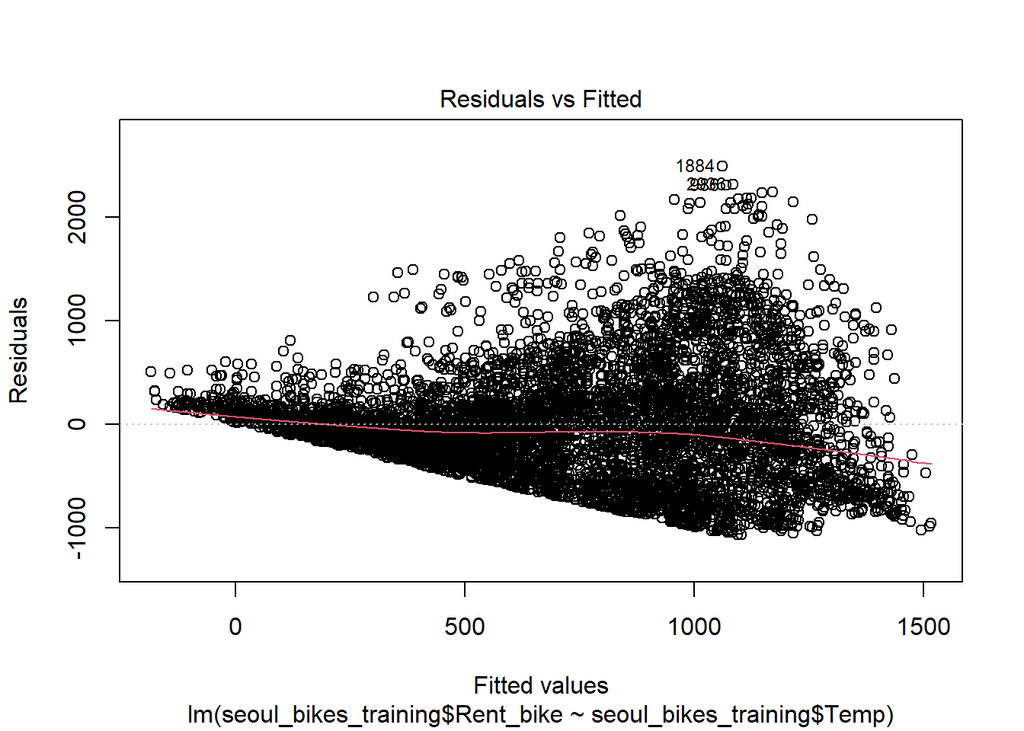

```r
plot(seoul.lm, which = c(1))
```

Osserviamo che alcuni dei valori generati dal modello sono inferiori a zero. Questi valori sono per forza sbagliati poichè noi vogliamo predirre il numero di bici da rendere disponibili che sarà sempre maggiore o uguale a zero. Per evitare che questo accada costruiamo un modello predittivo per sqrt(‘Rent_bike’) e non più per ‘Rent_bike’. In questo modo i valori assunti da ‘Rent_bike’ dovranno essere per forza numeri postivi poichè il dominio della radice è l’insieme dei numeri reali maggiori di zero.

```r
seoul_sqrt.plm <- update(seoul.plm, sqrt(.) ~ .)
summary(seoul_sqrt.plm)
```

```
##
## Call:
## lm(formula = sqrt(seoul_bikes_training$Rent_bike) ~ seoul_bikes_training$Temp +
##     seoul_bikes_training$Hour + seoul_bikes_training$Vis)
##
## Residuals:
##     Min      1Q  Median      3Q     Max
## -32.200  -5.080  -0.080   5.247  28.443
##
## Coefficients:
##                            Estimate Std. Error t value Pr(>|t|)
## (Intercept)               4.8058013  0.3080494   15.60   <2e-16 ***
## seoul_bikes_training$Temp 0.5399073  0.0083134   64.94   <2e-16 ***
## seoul_bikes_training$Hour 0.5851464  0.0145853   40.12   <2e-16 ***
## seoul_bikes_training$Vis  0.0036170  0.0001648   21.95   <2e-16 ***
## ---
## Signif. codes:  0 '***' 0.001 '**' 0.01 '*' 0.05 '.' 0.1 ' ' 1
##
## Residual standard error: 8.218 on 6768 degrees of freedom
## Multiple R-squared:  0.5193, Adjusted R-squared:  0.5191
## F-statistic:  2437 on 3 and 6768 DF,  p-value: < 2.2e-16
```

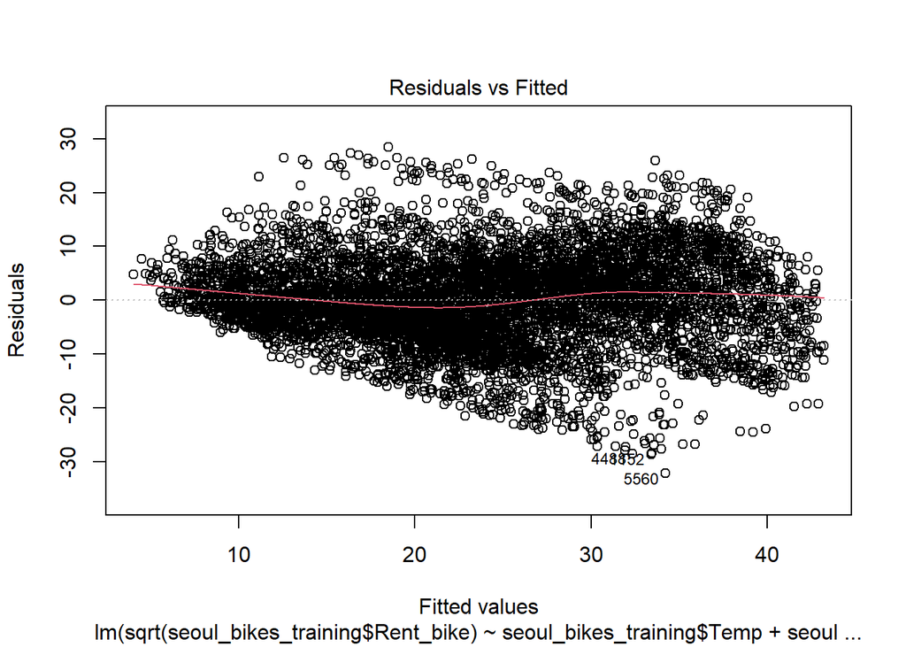

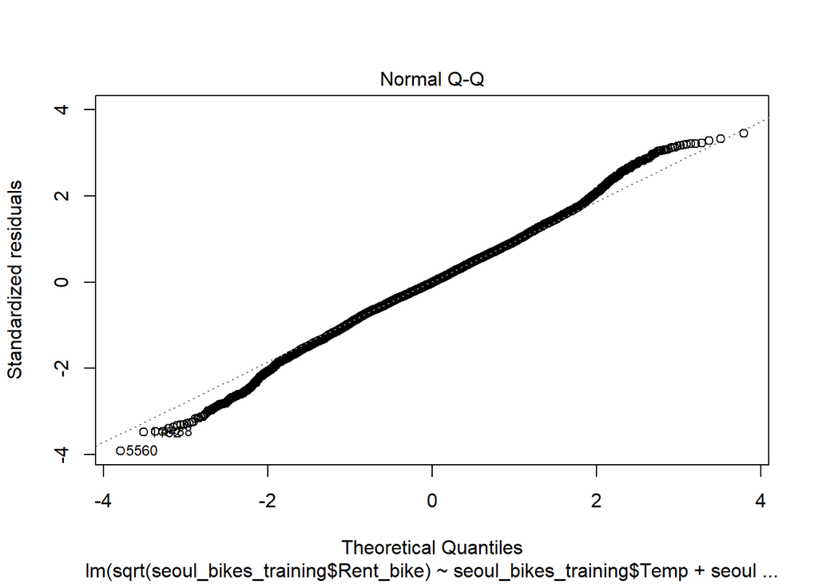

```r
plot(seoul_sqrt.plm, which = c(1,2))
```

Otteniamo un miglioramento dell’indice R^2 e il modello non genera più valori negativi, come previsto. Dal grafico dei quantili teorici di una distribuzione normale contro i residui standardizzati del modello osserviamo che il comportamento del modello è ottimo per valori attorno alla mediana della distribuzione dei residui standardizzati mentre si discosta abbastanza da quello atteso per valori estremi.  
L’ultima variabile quantitativa che potremmo voler inserire è ‘Hum’(Humidity) ma risulta fortemente correlata con ‘Vis’. Le variabili ‘Rf’(Rain fall) e ‘WS’(Wind Speed) non le inseriamo perchè hanno una correlazione estremamente bassa con la variabile target.  
Dalle analisi inziali sembra che le variabili qualitative ‘Hol’(Holiday) e ‘Seas’(Season) abbiano un impatto sul numero di bici affitatte. Decidiamo quindi di inserirle entrambe nel modello.

```r
seoul_sqrt.plm <- update(seoul_sqrt.plm, . ~ . + seoul_bikes_training$Hol + seoul_bikes_training$Seas)
summary(seoul_sqrt.plm)
```

```
##
## Call:
## lm(formula = sqrt(seoul_bikes_training$Rent_bike) ~ seoul_bikes_training$Temp +
##     seoul_bikes_training$Hour + seoul_bikes_training$Vis + seoul_bikes_training$Hol +
##     seoul_bikes_training$Seas)
##
## Residuals:
##     Min      1Q  Median      3Q     Max
## -35.412  -4.593   0.133   4.651  27.741
##
## Coefficients:
##                                      Estimate Std. Error t value Pr(>|t|)
## (Intercept)                         5.3493513  0.6074306   8.807  < 2e-16 ***
## seoul_bikes_training$Temp           0.5077907  0.0164905  30.793  < 2e-16 ***
## seoul_bikes_training$Hour           0.5913303  0.0144301  40.979  < 2e-16 ***
## seoul_bikes_training$Vis            0.0036342  0.0001626  22.346  < 2e-16 ***
## seoul_bikes_training$HolNo Holiday  3.0123189  0.4587285   6.567 5.53e-11 ***
## seoul_bikes_training$SeasSpring    -2.2418381  0.2829342  -7.924 2.68e-15 ***
## seoul_bikes_training$SeasSummer    -4.5458994  0.3471875 -13.093  < 2e-16 ***
## seoul_bikes_training$SeasWinter    -5.3037851  0.3888105 -13.641  < 2e-16 ***
## ---
## Signif. codes:  0 '***' 0.001 '**' 0.01 '*' 0.05 '.' 0.1 ' ' 1
##
## Residual standard error: 7.938 on 6764 degrees of freedom
## Multiple R-squared:  0.5518, Adjusted R-squared:  0.5513
## F-statistic:  1189 on 7 and 6764 DF,  p-value: < 2.2e-16
```

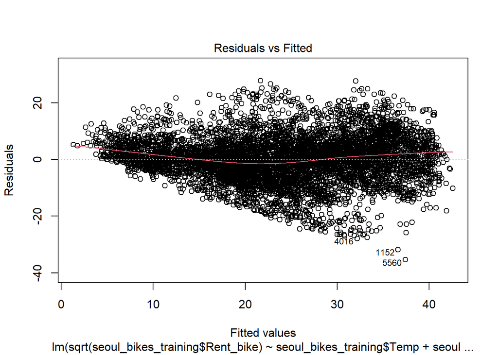

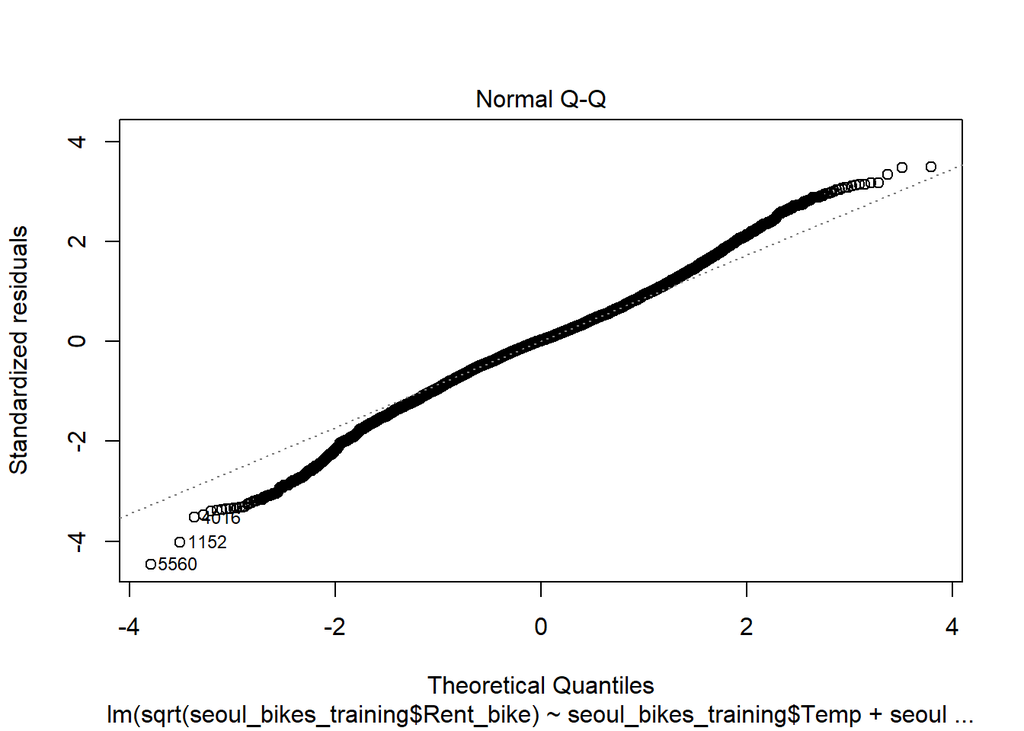

```r
plot(seoul_sqrt.plm, which = c(1,2))
```

Il miglioramento non è particolarmente significativo ma le variabili risultano tutte significative, decidiamo quindi di confermare l’inserimento di entrambe le variabili qualitative nel modello.  
Potremmo provare a togliere l’intercetta per tentare di migliorare il modello ma considerazioni qualitative ci sconsigliano di farlo. Togliere l’intercetta significa infatti supporre che il grafico del nostro modello di regressione passi per l’origine ma possiamo affermare con certezza che questo non è vero. Per ‘Hour’ uguale a zero abbiamo infatti osservato nelle analisi iniziali che il numero di bici affittate è diverso da zero.  
Proviamo quindi ad inserire le variabili qualitative ‘Month’ e ‘Day’ che dalle analisi iniziali sembravano avere un impatto sul numero di bici affittate.

```r
seoul_bikes_training[,'Month'] <- as.factor(seoul_bikes_training[,'Month'])
seoul_bikes_training[,'Day'] <- as.factor(seoul_bikes_training[,'Day'])

seoul_sqrt.plm <- update(seoul_sqrt.plm, . ~ . + seoul_bikes_training$Day + seoul_bikes_training$Month)
summary(seoul_sqrt.plm)
```

```
##
## Call:
## lm(formula = sqrt(seoul_bikes_training$Rent_bike) ~ seoul_bikes_training$Temp +
##     seoul_bikes_training$Hour + seoul_bikes_training$Vis + seoul_bikes_training$Hol +
##     seoul_bikes_training$Seas + seoul_bikes_training$Day + seoul_bikes_training$Month)
##
## Residuals:
##     Min      1Q  Median      3Q     Max
## -38.035  -4.349  -0.079   4.450  26.073
##
## Coefficients: (3 not defined because of singularities)
##                                      Estimate Std. Error t value Pr(>|t|)
## (Intercept)                         3.775e+00  6.481e-01   5.824 6.02e-09 ***
## seoul_bikes_training$Temp           7.324e-01  2.084e-02  35.148  < 2e-16 ***
## seoul_bikes_training$Hour           5.302e-01  1.405e-02  37.739  < 2e-16 ***
## seoul_bikes_training$Vis            4.839e-03  1.644e-04  29.430  < 2e-16 ***
## seoul_bikes_training$HolNo Holiday  2.940e+00  4.382e-01   6.710 2.11e-11 ***
## seoul_bikes_training$SeasSpring    -4.700e+00  5.101e-01  -9.212  < 2e-16 ***
## seoul_bikes_training$SeasSummer    -1.519e+01  6.531e-01 -23.261  < 2e-16 ***
## seoul_bikes_training$SeasWinter    -4.350e+00  5.067e-01  -8.583  < 2e-16 ***
## seoul_bikes_training$Day2           8.952e-01  3.425e-01   2.614 0.008976 **
## seoul_bikes_training$Day3           7.772e-01  3.377e-01   2.302 0.021382 *
## seoul_bikes_training$Day4           5.485e-01  3.378e-01   1.624 0.104444
## seoul_bikes_training$Day5           1.537e+00  3.380e-01   4.546 5.56e-06 ***
## seoul_bikes_training$Day6           1.782e-01  3.369e-01   0.529 0.596912
## seoul_bikes_training$Day7          -1.410e+00  3.359e-01  -4.200 2.71e-05 ***
## seoul_bikes_training$Month2        -1.284e+00  4.490e-01  -2.859 0.004263 **
## seoul_bikes_training$Month3         5.515e-01  4.928e-01   1.119 0.263100
## seoul_bikes_training$Month4        -2.062e-01  4.619e-01  -0.446 0.655326
## seoul_bikes_training$Month5                NA         NA      NA       NA
## seoul_bikes_training$Month6         1.157e+01  4.647e-01  24.910  < 2e-16 ***
## seoul_bikes_training$Month7         3.241e+00  4.372e-01   7.413 1.38e-13 ***
## seoul_bikes_training$Month8                NA         NA      NA       NA
## seoul_bikes_training$Month9        -7.214e+00  5.782e-01 -12.478  < 2e-16 ***
## seoul_bikes_training$Month10       -1.642e+00  4.815e-01  -3.411 0.000651 ***
## seoul_bikes_training$Month11               NA         NA      NA       NA
## seoul_bikes_training$Month12        9.824e-01  4.393e-01   2.236 0.025362 *
## ---
## Signif. codes:  0 '***' 0.001 '**' 0.01 '*' 0.05 '.' 0.1 ' ' 1
##
## Residual standard error: 7.484 on 6750 degrees of freedom
## Multiple R-squared:  0.6024, Adjusted R-squared:  0.6012
## F-statistic:   487 on 21 and 6750 DF,  p-value: < 2.2e-16
```

## Testing del modello

```r
seoul_bikes[,'Month'] <- as.factor(seoul_bikes[,'Month'])
seoul_bikes[,'Day'] <- as.factor(seoul_bikes[,'Day'])
```

```r
set.seed(125)

train_control <- trainControl(method = "repeatedcv",
                              number = 10, repeats = 3)

seoul_sqrt.plm_kval <- train(sqrt(Rent_bike) ~ Hour + Temp + Vis + Hol + Seas, data = seoul_bikes,
               method = "lm",
               trControl = train_control)

print(seoul_sqrt.plm_kval)
```

```
## Linear Regression
##
## 8465 samples
##    5 predictor
##
## No pre-processing
## Resampling: Cross-Validated (10 fold, repeated 3 times)
## Summary of sample sizes: 7618, 7618, 7617, 7618, 7618, 7620, ...
## Resampling results:
##
##   RMSE      Rsquared   MAE
##   7.994748  0.5455947  6.040705
##
## Tuning parameter 'intercept' was held constant at a value of TRUE
```

```r
set.seed(125)

train_control <- trainControl(method = "repeatedcv",
                              number = 10, repeats = 3)

options(warn=-1)
seoul_sqrt.plm_kval <- train(sqrt(Rent_bike) ~ Hour + Temp + Vis + Hol + Seas + Month + Date, data = seoul_bikes,
               method = "lm",
               trControl = train_control)

print(seoul_sqrt.plm_kval)
```

```
## Linear Regression
##
## 8465 samples
##    7 predictor
##
## No pre-processing
## Resampling: Cross-Validated (10 fold, repeated 3 times)
## Summary of sample sizes: 7618, 7618, 7617, 7618, 7618, 7620, ...
## Resampling results:
##
##   RMSE      Rsquared   MAE
##   7.573145  0.5923724  5.722241
##
## Tuning parameter 'intercept' was held constant at a value of TRUE
```

```r
seoul_bikes_training[,'Month'] <- as.factor(seoul_bikes_training[,'Month'])
seoul_bikes_training[,'Day'] <- as.factor(seoul_bikes_training[,'Day'])
seoul_bikes_test[,'Month'] <- as.factor(seoul_bikes_test[,'Month'])
seoul_bikes_test[,'Day'] <- as.factor(seoul_bikes_test[,'Day'])

seoul_sqrt.plm <- lm(sqrt(Rent_bike) ~ Hour + Temp + Vis + Hol + Seas + Month + Date, data = seoul_bikes_training)
```

```r
model_values <- predict(seoul_sqrt.plm, seoul_bikes_test)
model_values <- round(model_values, digits = 0)

differenze <- (abs(seoul_bikes_test$Rent_bike - model_values^2))

prestazioni <- c()
num_1=0
num_0=0

for(i in 1:length(model_values)){

  if(differenze[i] <= quantile(seoul_bikes_test$Rent_bike, 0.3)){
    prestazioni[i]=1
    num_1 = num_1 + 1
  } else{
    prestazioni[i]=0
    num_0 = num_0 + 1
  }
}

print(num_1/(num_1 + num_0))
```

```
## [1] 0.6184288
```

## Conclusioni

Le prestazioni del modello sono soddisfacenti ma migliorabili.  
Rimangono inutilizzate diverse variabili atmosferiche del dataset iniziale. Per migliorare il modello potrebbe risultare utile una classificazione basata su tali variabili per costruire una nuova variabile che aggregasse le condizioni atmosferiche.  
Sarebbe inoltre utile avere dei costi degli errori per poter sviluppare una valutazione delle prestazioni più specifica. Possiamo supporre ad esempio che fornire meno bici di quelle necessarie sia un errore più grave rispetto al fornirne di più.